# Atividade 2

Author

Mikael Marin Coletto

Published

November 28, 2024

# Questão 1

Considere o quadro de notas abaixo referente a estudo para comparar a eficiência de dois métodos de aprendizagem. Utilize o teste de Wilcoxon para testar se existe diferença entre os dois métodos.

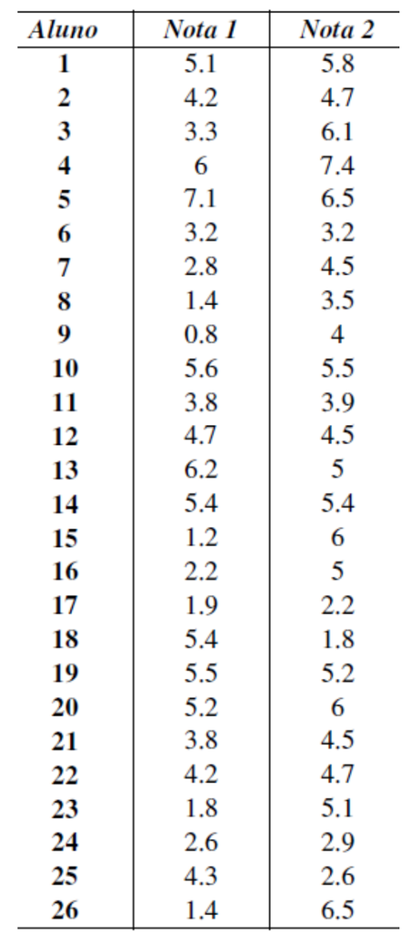

Tabela 1

**R:** O teste de Wilcoxon analisa duas amostras e verifica se os tratamentos diferente entre si, para duas amostras pareadas.

H0: Os tratamentos não diferem. (nota 1 = nota 2)

H1: Os tratamentos diferem. (nota 1 $\neq$ nota 2)

```r
## Dados
data <- data.frame(
  aluno = 1:26,
  nota1 = c(5.1, 4.2, 3.3, 6.0, 7.1, 3.2, 2.8, 1.4, 0.8, 5.6,
            3.8, 4.7, 6.2, 5.4, 1.2, 2.2, 1.9, 5.4, 5.5, 5.2,
            3.8, 4.2, 1.8, 2.6, 4.3, 1.4),
  nota2 = c(5.8, 4.7, 6.1, 7.4, 6.5, 3.2, 4.5, 3.5, 4.0, 5.5,
            3.9, 4.5, 5.0, 5.4, 6.0, 5.0, 2.2, 1.8, 5.2, 6.0,
            4.5, 4.7, 5.1, 2.9, 2.6, 6.5)
)


## Teste de Wilcox
teste <- wilcox.test(data$nota1, data$nota2, paired = TRUE, alternative = "two.sided")
teste
```

```
    Wilcoxon signed rank test with continuity correction

data:  data$nota1 and data$nota2
V = 67.5, p-value = 0.01911
alternative hypothesis: true location shift is not equal to 0
```

Usando o nível de significância de 5%, Tivemos então um p-valor de 0.0191122 e como ele é menor que 0.05, rejeitamos a hipótese nula. Ou seja, há evidências para rejeitar a hipótese de que os tratamentos não diferem. Portanto, podemos dizer que os métodos de aprendizagem não são equivalentes.

# Questão 2

Um estudo foi realizado para avaliar o efeito de um programa de dieta. Os mesmos participantes foram avaliados antes e depois de participarem do programa. Os resultados são resumidos na seguinte tabela:

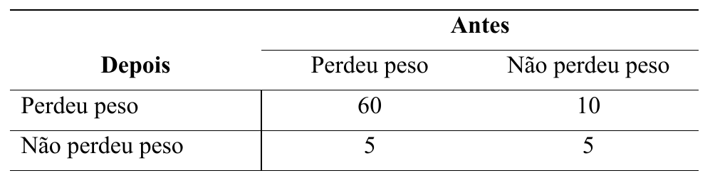

Tabela 2

**R:** Para estes dados, usaremos o teste de McNemar para avaliar se houve um deslocamento (ou seja, houve uma diferença) entre os participantes que participaram do programa de dieta.

H0: Os tratamentos não diferem. (antes do programa = depois do programa)

H1: Os tratamentos diferem. (antes do programa $\neq$ depois do programa)

```r
## Dados
tabela <- matrix(c(60, 10, 5, 5), nrow = 2, byrow = TRUE,
                 dimnames = list(
                   "Depois" = c("Perdeu peso", "Não perdeu peso"),
                   "Antes" = c("Perdeu peso", "Não perdeu peso")
                 ))

# Convertendo para tabela
tabela <- as.table(tabela)


## Teste de McNemar
teste <- mcnemar.test(tabela)
teste
```

```
    McNemar's Chi-squared test with continuity correction

data:  tabela
McNemar's chi-squared = 1.0667, df = 1, p-value = 0.3017
```

Usando o nível de significância de 5%, Tivemos então um p-valor de 0.3016996 e como ele é maior que 0.05, não rejeitamos a hipótese nula. Ou seja, não há evidências para rejeitar a hipótese de que os tratamentos não diferem. Portanto, podemos dizer que o programa de dieta não teve um efeito significativo na perda de peso dos participantes.